# chapter5.Rmd

Maarit

12/2/2019

# Dimension reduction

To start with dimension reduction, first let’s read the data:

```r
human<-read.csv("http://s3.amazonaws.com/assets.datacamp.com/production/course_2218/datasets/human2.txt", header=TRUE, sep= ",")
str(human)
```

```
## 'data.frame':    155 obs. of  8 variables:
##  $ Edu2.FM  : num  1.007 0.997 0.983 0.989 0.969 ...
##  $ Labo.FM  : num  0.891 0.819 0.825 0.884 0.829 ...
##  $ Edu.Exp  : num  17.5 20.2 15.8 18.7 17.9 16.5 18.6 16.5 15.9 19.2 ...
##  $ Life.Exp : num  81.6 82.4 83 80.2 81.6 80.9 80.9 79.1 82 81.8 ...
##  $ GNI      : int  64992 42261 56431 44025 45435 43919 39568 52947 42155 32689 ...
##  $ Mat.Mor  : int  4 6 6 5 6 7 9 28 11 8 ...
##  $ Ado.Birth: num  7.8 12.1 1.9 5.1 6.2 3.8 8.2 31 14.5 25.3 ...
##  $ Parli.F  : num  39.6 30.5 28.5 38 36.9 36.9 19.9 19.4 28.2 31.4 ...
```

## Item 1 Visualization of the data.

```r
library(GGally)
library(dplyr)
```

Let us calculate a correlation matrix and then using the %>% -function draw a correlation plot:

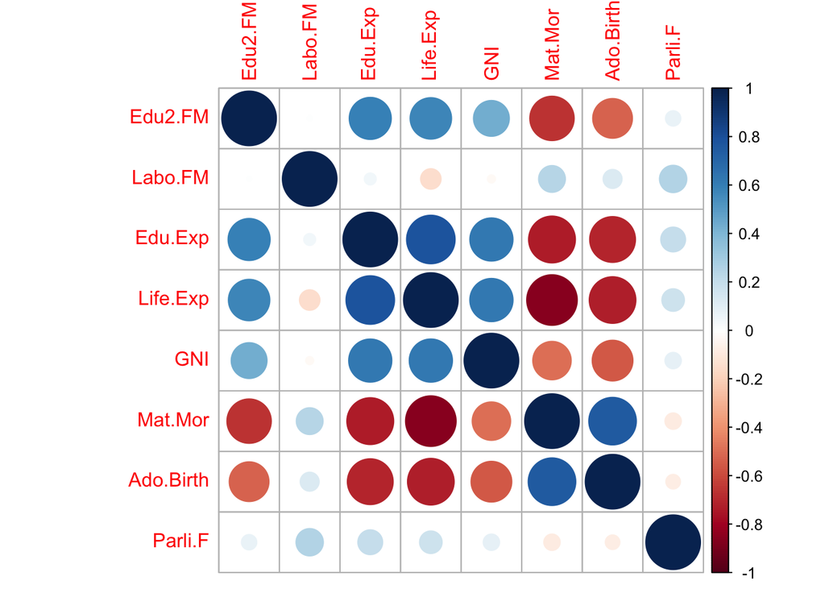

```r
library(corrplot)
cor(human) %>%corrplot()
```

Here we can see that Life expectancy at birth and expected years of schooling have a strong positive correlation. Maternal mortality rate and adolescent birth rate also have a strong positive correlation. Maternal mortality has strongest negative correlation with life expectancy, and also a quite strong negative correlation with female/male proportion of secondary education, and expected years of schooling. Adolescent birth rate and life expectancy correlate negatively.

## Item 2. Principal component analysis on unstandardized data “human”

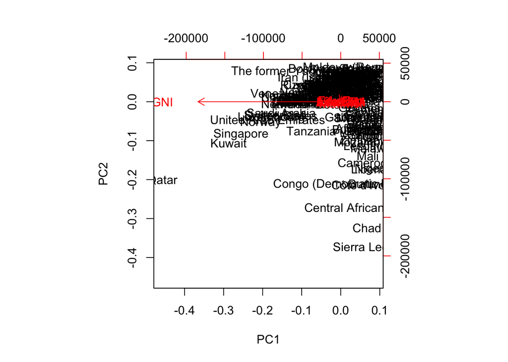

```r
pca_human <- prcomp(human)
biplot(pca_human, choices = 1:2)
```

```r
s <- summary(pca_human)
pca_pr <- round(100*s$importance[2, ], digits = 1)
```

R can’t properly produce the PCA on unstandardized data. Here the arrow just shows strong negative correlation between GNI and prinicipal component 1, the other variables remaining unclear. So let’s standardize the data:

## Item 3. Working with standardized data and biplotting it:

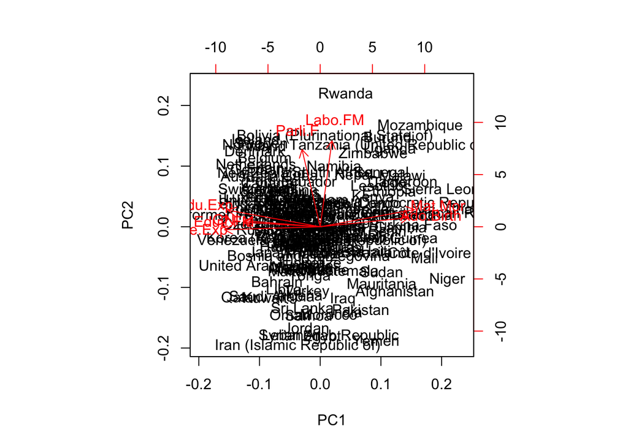

```r
human_std <- scale(human)
pca_human <- prcomp(human_std)
biplot(pca_human, choices = 1:2)
```

The results seem a lot different after standardization. The reason is that PCA is sensitive to scaling of original features, and assumes that variables with more variance would be more significant than other. Thus, standardization of hte data is important.

In biplot, angle between variables shows the degree of correlation. Angle betwwn variable and principal component axes also similarly show correlation. Small angle= high correlation. Here we can see that maternal mortality and adolescent birth rate have high positive correlation to each other, and also to the PC1. Expected time in education, life expectancy and female/male education ratio have a positive correlation to each other, negative correalation with adolescence birth and maternal mortality ratio, as well as a negative correlation with PC1.

The female/male ratio of labour force participation and ratio of females in parliament show high positive correlation both with each other and PC2.

## Item 4 interpretation of the first two principal components

It seems that principal component 1 (PC1) is related with (un)survival, as it correlates positively with such societal issues as maternal mortality rate or adolescents births. Thus it has a negative correlation with issues that are related with better survival, such as life expectancy and expected years of schooling.

Principal component 2 (PC2) is related with variables that show higher levels of Maslow’s need hierarchy, such as participation in work froce (described by female/male ratio) or female participation in parliament. The variables related to PC2 thus show some higher developmental stage of the society.

## Item 5

Read data “Teatime” from the already installed FactoMineR -library:

```r
library("FactoMineR")
```

```r
data("tea")
```

```r
str(tea)
```

```
## 'data.frame':    300 obs. of  36 variables:
##  $ breakfast       : Factor w/ 2 levels "breakfast","Not.breakfast": 1 1 2 2 1 2 1 2 1 1 ...
##  $ tea.time        : Factor w/ 2 levels "Not.tea time",..: 1 1 2 1 1 1 2 2 2 1 ...
##  $ evening         : Factor w/ 2 levels "evening","Not.evening": 2 2 1 2 1 2 2 1 2 1 ...
##  $ lunch           : Factor w/ 2 levels "lunch","Not.lunch": 2 2 2 2 2 2 2 2 2 2 ...
##  $ dinner          : Factor w/ 2 levels "dinner","Not.dinner": 2 2 1 1 2 1 2 2 2 2 ...
##  $ always          : Factor w/ 2 levels "always","Not.always": 2 2 2 2 1 2 2 2 2 2 ...
##  $ home            : Factor w/ 2 levels "home","Not.home": 1 1 1 1 1 1 1 1 1 1 ...
##  $ work            : Factor w/ 2 levels "Not.work","work": 1 1 2 1 1 1 1 1 1 1 ...
##  $ tearoom         : Factor w/ 2 levels "Not.tearoom",..: 1 1 1 1 1 1 1 1 1 2 ...
##  $ friends         : Factor w/ 2 levels "friends","Not.friends": 2 2 1 2 2 2 1 2 2 2 ...
##  $ resto           : Factor w/ 2 levels "Not.resto","resto": 1 1 2 1 1 1 1 1 1 1 ...
##  $ pub             : Factor w/ 2 levels "Not.pub","pub": 1 1 1 1 1 1 1 1 1 1 ...
##  $ Tea             : Factor w/ 3 levels "black","Earl Grey",..: 1 1 2 2 2 2 2 1 2 1 ...
##  $ How             : Factor w/ 4 levels "alone","lemon",..: 1 3 1 1 1 1 1 3 3 1 ...
```

[output cut: 22 more lines]

```r
dim(tea)
```

```
## [1] 300  36
```

```r
library(tidyr)
library(dplyr)
library(ggplot2)
```

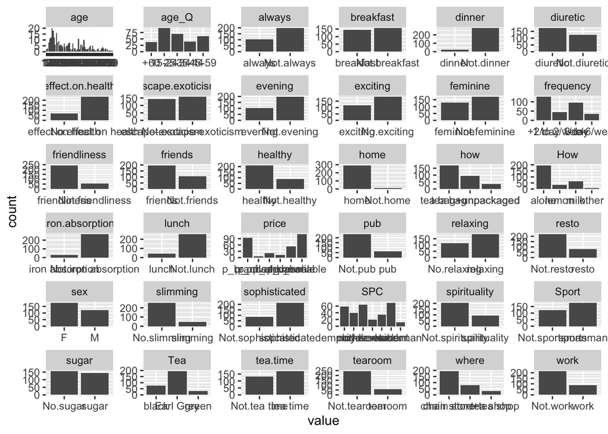

```r
gather(tea)  %>%  ggplot(aes(value)) + facet_wrap("key", scales = "free") + geom_bar()
```

Since the data is large, and difficult to read, let’s reduce the number of columns, and keep the following:

```r
keep_columns <- c("Tea", "How", "how", "sugar", "where", "lunch")
```

LEt’s create a data set “tea_time”

```r
tea_time <- select(tea,one_of(keep_columns))
```

```r
str(tea_time)
```

```
## 'data.frame':    300 obs. of  6 variables:
##  $ Tea  : Factor w/ 3 levels "black","Earl Grey",..: 1 1 2 2 2 2 2 1 2 1 ...
##  $ How  : Factor w/ 4 levels "alone","lemon",..: 1 3 1 1 1 1 1 3 3 1 ...
##  $ how  : Factor w/ 3 levels "tea bag","tea bag+unpackaged",..: 1 1 1 1 1 1 1 1 2 2 ...
##  $ sugar: Factor w/ 2 levels "No.sugar","sugar": 2 1 1 2 1 1 1 1 1 1 ...
##  $ where: Factor w/ 3 levels "chain store",..: 1 1 1 1 1 1 1 1 2 2 ...
##  $ lunch: Factor w/ 2 levels "lunch","Not.lunch": 2 2 2 2 2 2 2 2 2 2 ...
```

```r
summary(tea_time)
```

```
##         Tea         How                      how           sugar
##  black    : 74   alone:195   tea bag           :170   No.sugar:155
##  Earl Grey:193   lemon: 33   tea bag+unpackaged: 94   sugar   :145
##  green    : 33   milk : 63   unpackaged        : 36
##                  other:  9
##                   where           lunch
##  chain store         :192   lunch    : 44
##  chain store+tea shop: 78   Not.lunch:256
##  tea shop            : 30
##
```

Now see how this looks as a plot:

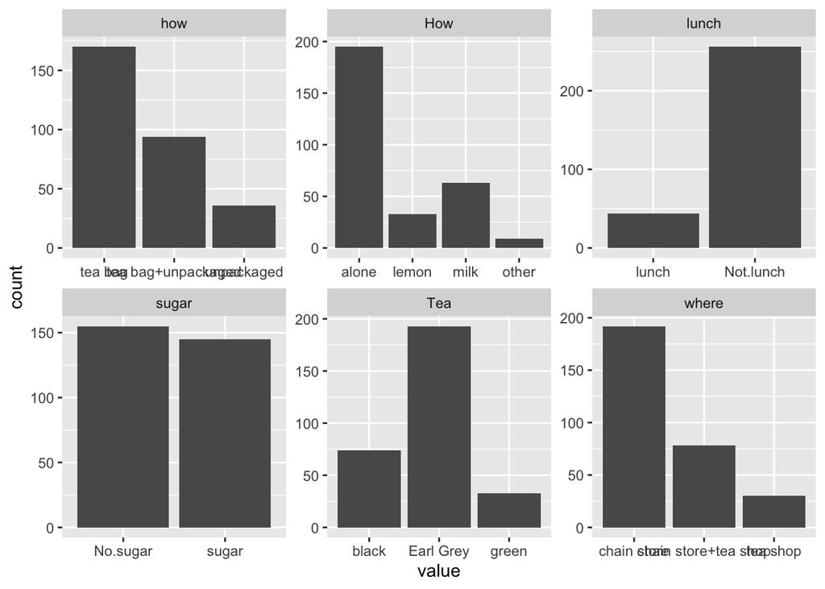

```r
gather(tea_time) %>% ggplot(aes(value), theme(axis.text.x = element_text(angle = 45, hjust = 1, size = 4))) + facet_wrap("key", scales = "free") + geom_bar()
```

The bars show distribution of consumers different habits related with tea consumption: Most common is to prepare it from tea bag, drink it alone, not related with lunch. Sugar vs no sugar are almost even, whereas Earl Grey is the most popular quality, and tea is mostly bought from chain stores.

To perform a multiple correspondence analysis on the “tea_time” data, and see the summary of the model:

```r
mca <- MCA(tea_time, graph = FALSE)
summary(mca)
```

```
##
## Call:
## MCA(X = tea_time, graph = FALSE)
##
##
## Eigenvalues
##                        Dim.1   Dim.2   Dim.3   Dim.4   Dim.5   Dim.6
## Variance               0.279   0.261   0.219   0.189   0.177   0.156
## % of var.             15.238  14.232  11.964  10.333   9.667   8.519
## Cumulative % of var.  15.238  29.471  41.435  51.768  61.434  69.953
##                        Dim.7   Dim.8   Dim.9  Dim.10  Dim.11
## Variance               0.144   0.141   0.117   0.087   0.062
## % of var.              7.841   7.705   6.392   4.724   3.385
## Cumulative % of var.  77.794  85.500  91.891  96.615 100.000
##
## Individuals (the 10 first)
##                       Dim.1    ctr   cos2    Dim.2    ctr   cos2    Dim.3
## 1                  | -0.298  0.106  0.086 | -0.328  0.137  0.105 | -0.327
## 2                  | -0.237  0.067  0.036 | -0.136  0.024  0.012 | -0.695
## 3                  | -0.369  0.162  0.231 | -0.300  0.115  0.153 | -0.202
## 4                  | -0.530  0.335  0.460 | -0.318  0.129  0.166 |  0.211
## 5                  | -0.369  0.162  0.231 | -0.300  0.115  0.153 | -0.202
## 6                  | -0.369  0.162  0.231 | -0.300  0.115  0.153 | -0.202
## 7                  | -0.369  0.162  0.231 | -0.300  0.115  0.153 | -0.202
## 8                  | -0.237  0.067  0.036 | -0.136  0.024  0.012 | -0.695
## 9                  |  0.143  0.024  0.012 |  0.871  0.969  0.435 | -0.067
## 10                 |  0.476  0.271  0.140 |  0.687  0.604  0.291 | -0.650
##                       ctr   cos2
## 1                   0.163  0.104 |
## 2                   0.735  0.314 |
## 3                   0.062  0.069 |
## 4                   0.068  0.073 |
## 5                   0.062  0.069 |
## 6                   0.062  0.069 |
## 7                   0.062  0.069 |
## 8                   0.735  0.314 |
## 9                   0.007  0.003 |
## 10                  0.643  0.261 |
##
## Categories (the 10 first)
```

[output cut: 16 more lines]

```
## lemon                0.035   3.226 |   1.329  14.771   0.218   8.081 |
## milk                 0.020   2.422 |   0.013   0.003   0.000   0.116 |
## other                0.102   5.534 |  -2.524  14.526   0.197  -7.676 |
## tea bag              0.161  -6.941 |  -0.065   0.183   0.006  -1.287 |
## tea bag+unpackaged   0.478  11.956 |   0.019   0.009   0.000   0.226 |
## unpackaged           0.141  -6.482 |   0.257   0.602   0.009   1.640 |
##
## Categorical variables (eta2)
##                      Dim.1 Dim.2 Dim.3
## Tea                | 0.126 0.108 0.410 |
## How                | 0.076 0.190 0.394 |
## how                | 0.708 0.522 0.010 |
## sugar              | 0.065 0.001 0.336 |
## where              | 0.702 0.681 0.055 |
## lunch              | 0.000 0.064 0.111 |
```

Of the categories, based on the coordinates of categories, earl grey, alone, tea bag, and milk are located close to each other, on the negative coordinate. From v-test results we can see that dimension 1 has a strong negative correlation with teabags, and strong positive correlation with unpackaged tea. Earl grey is also negatively correlated with Dim 1, whereas Black tea correlates positively.

Draw a plot of the MCA, in which the variables are shown in different colors:

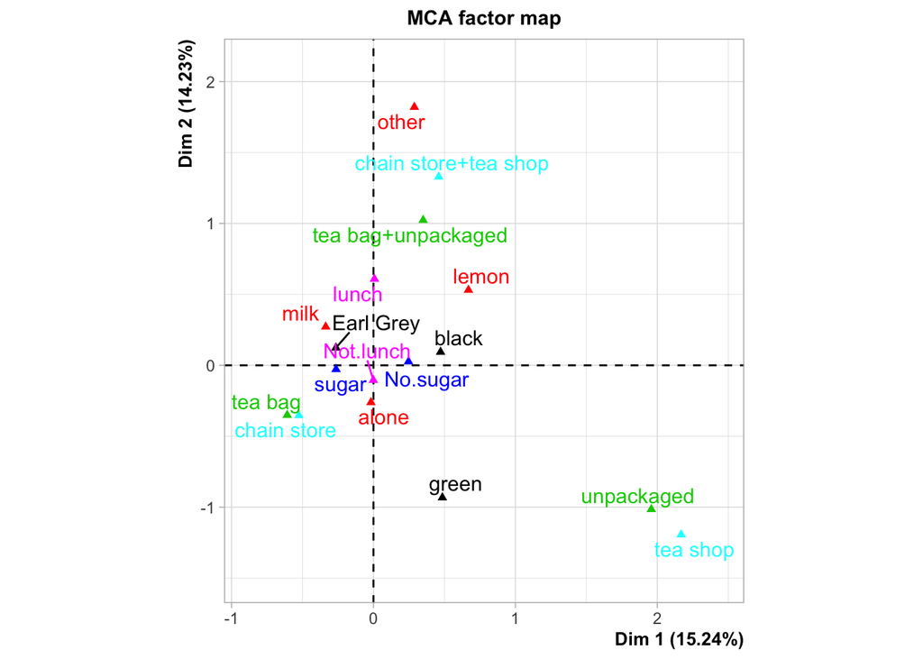

```r
plot(mca, invisible=c("ind"), habillage="quali")
```